# Berlin Airbnb Rental Demand Prediction - Model Development

Data Science Team

2025-03-22

# Introduction

This document covers the model development process for predicting Airbnb rental demand in Berlin. We will use the preprocessed data with the `demand_proxy` target variable created during the data preprocessing step.

In this improved approach, we’ve implemented several techniques to address overfitting:

1. **PCA (Principal Component Analysis)** for dimensionality reduction
2. **Cross-validation** for more robust model evaluation
3. **Multiple models comparison** to select the best performer
4. **Hyperparameter tuning** to optimize model complexity
5. **Feature selection** based on importance

## Data Loading

```r
# Define file paths
processed_data_path <- "../data/processed/"
models_path <- "../models/"
results_path <- "../results/"

# Load the processed data
train_data <- read.csv(paste0(processed_data_path, "train_berlin_clean.csv"))
test_data <- read.csv(paste0(processed_data_path, "test_berlin_clean.csv"))

# Print basic information about the datasets
cat(paste("Loaded train dataset with", nrow(train_data), "rows and", ncol(train_data), "columns"))
```

```
## Loaded train dataset with 15692 rows and 43 columns
```

```r
cat(paste("\nLoaded test dataset with", nrow(test_data), "rows and", ncol(test_data), "columns"))
```

```
##
## Loaded test dataset with 7842 rows and 38 columns
```

```r
# Display the first few rows of the training data
kable(head(train_data[, c("listing_id", "neighbourhood", "room_type", "price", "reviews", "demand_proxy")]),
     caption = "Preview of Training Data")
```

Preview of Training Data

| listing_id | neighbourhood | room_type | price | reviews | demand_proxy |
| --- | --- | --- | --- | --- | --- |
| 19665213 | Prenzlauer Berg | Private room | 26 | 6 | 0.2570755 |
| 6436842 | Pankow | Entire home/apt | 41 | 6 | 0.2570755 |
| 10559468 | Prenzlauer Berg | Entire home/apt | 50 | 2 | 0.1273585 |
| 27215482 | Friedrichshain | Private room | 50 | 4 | 0.1297170 |
| 27287546 | Prenzlauer Berg | Private room | 55 | 0 | 0.0000000 |
| 26590915 | Mariendorf | Private room | 39 | 10 | 0.2617925 |

# Data Preparation for Modeling

Before we start modeling, we need to prepare the data by handling missing values and converting categorical variables to factors.

```r
# Check for any lingering NA values
train_na_counts <- colSums(is.na(train_data))
na_columns <- train_na_counts[train_na_counts > 0]

# Display columns with missing values
if(length(na_columns) > 0) {
  kable(data.frame(
    Column = names(na_columns),
    Missing_Values = na_columns
  ), caption = "Columns with Missing Values")
}
```

Columns with Missing Values

|  | Column | Missing_Values |
| --- | --- | --- |
| listing_id | listing_id | 1 |
| square_feet | square_feet | 15389 |
| overall_rating | overall_rating | 2962 |
| accuracy_rating | accuracy_rating | 2971 |
| cleanliness_rating | cleanliness_rating | 2970 |
| checkin_rating | checkin_rating | 2973 |
| communication_rating | communication_rating | 2970 |
| location_rating | location_rating | 2971 |
| value_rating | value_rating | 2972 |
| price | price | 9 |
| price_bin | price_bin | 9 |

```r
# Simple imputation for remaining NAs to avoid modeling errors
# For numeric columns, use median; for categorical, use most frequent value
train_data <- train_data %>%
  mutate(across(where(is.numeric), ~ifelse(is.na(.), median(., na.rm = TRUE), .)),
         across(where(is.character), ~ifelse(is.na(.), "Unknown", .)))

# Convert categorical variables to factors for modeling
# Include more categorical variables that might be important predictors
cat_columns <- c("neighborhood_group", "property_type", "room_type",
                "host_response_time", "is_superhost", "instant_bookable")

# Check the number of levels in each categorical column
for (col in cat_columns) {
  if (col %in% names(train_data)) {
    num_levels <- length(unique(train_data[[col]]))
    cat(paste("Column", col, "has", num_levels, "unique values\n"))
  }
}
```

```
## Column neighborhood_group has 12 unique values
## Column property_type has 16 unique values
## Column room_type has 3 unique values
## Column host_response_time has 5 unique values
## Column is_superhost has 3 unique values
## Column instant_bookable has 2 unique values
```

```r
# Convert selected categorical columns to factors
train_data <- train_data %>%
  mutate(across(all_of(cat_columns), as.factor))

# Feature Selection: Select features that are likely to be important for demand prediction
features <- setdiff(names(train_data),
                   c("listing_id", "listing_name", "host_id", "host_name",
                     "city", "country", "country_code", "postal_code",
                     "first_review", "last_review", "host_since",
                     "demand_proxy", "demand_proxy_reviews", # These are our targets
                     "neighbourhood", # Too many levels for RandomForest
                     # Remove highly correlated features
                     "room_type_entire", "room_type_private", "room_type_shared"))

# Target variable
cat("Using demand_proxy as target variable for model development")
```

```
## Using demand_proxy as target variable for model development
```

# Train-Validation Split

We’ll create a training and validation set to evaluate our model performance.

```r
# Create training and validation sets (70% train, 30% validation)
set.seed(42) # For reproducibility
train_index <- createDataPartition(train_data$demand_proxy, p = 0.7, list = FALSE)
train_set <- train_data[train_index, ]
valid_set <- train_data[-train_index, ]

cat(paste("Training set size:", nrow(train_set), "rows"))
```

```
## Training set size: 10986 rows
```

```r
cat(paste("\nValidation set size:", nrow(valid_set), "rows"))
```

```
##
## Validation set size: 4706 rows
```

# Feature Engineering and Dimensionality Reduction

To prevent overfitting, we’ll apply PCA (Principal Component Analysis) to reduce dimensionality.

```r
# Separate numerical and categorical features
numeric_features <- names(train_set)[sapply(train_set, is.numeric)]
numeric_features <- setdiff(numeric_features, "demand_proxy")
categorical_features <- names(train_set)[sapply(train_set, is.factor)]

# Display selected features
cat("Selected numeric features:", length(numeric_features), "\n")
```

```
## Selected numeric features: 16
```

```r
cat("Selected categorical features:", length(categorical_features), "\n")
```

```
## Selected categorical features: 6
```

```r
# Create dummy variables for categorical features (one-hot encoding)
dummy_model <- dummyVars(~., data = train_set[, c(categorical_features)])
train_dummy <- predict(dummy_model, newdata = train_set[, c(categorical_features)])
valid_dummy <- predict(dummy_model, newdata = valid_set[, c(categorical_features)])

# Combine numeric and dummy variables
train_combined <- cbind(train_set[, numeric_features], train_dummy)
valid_combined <- cbind(valid_set[, numeric_features], valid_dummy)

# Check for correlation among features
correlation_matrix <- cor(train_combined)
high_corr_threshold <- 0.75
high_corr_features <- findCorrelation(correlation_matrix, cutoff = high_corr_threshold)
cat(paste("Found", length(high_corr_features), "highly correlated features (r >", high_corr_threshold, ")\n"))
```

```
## Found 4 highly correlated features (r > 0.75 )
```

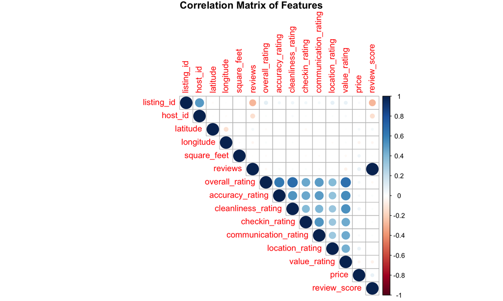

```r
# Visualize correlation matrix for selected features (limit to top 15 for visibility)
corrplot(correlation_matrix[1:min(15, ncol(correlation_matrix)),
                           1:min(15, ncol(correlation_matrix))],
        method = "circle", type = "upper",
        title = "Correlation Matrix of Features",
        mar = c(0, 0, 1, 0))
```

```r
# Apply PCA for dimensionality reduction
# First, normalize the data (center and scale)
preproc <- preProcess(train_combined, method = c("center", "scale"))
train_normalized <- predict(preproc, train_combined)
valid_normalized <- predict(preproc, valid_combined)

# Perform PCA
pca_model <- prcomp(train_normalized)

# Analyze variance explained by principal components
variance_explained <- pca_model$sdev^2 / sum(pca_model$sdev^2)
cumulative_variance <- cumsum(variance_explained)

# Determine number of components to retain 90% of variance
n_components <- which(cumulative_variance >= 0.9)[1]
cat(paste("Number of PCA components to retain 90% variance:", n_components))
```

```
## Number of PCA components to retain 90% variance: 38
```

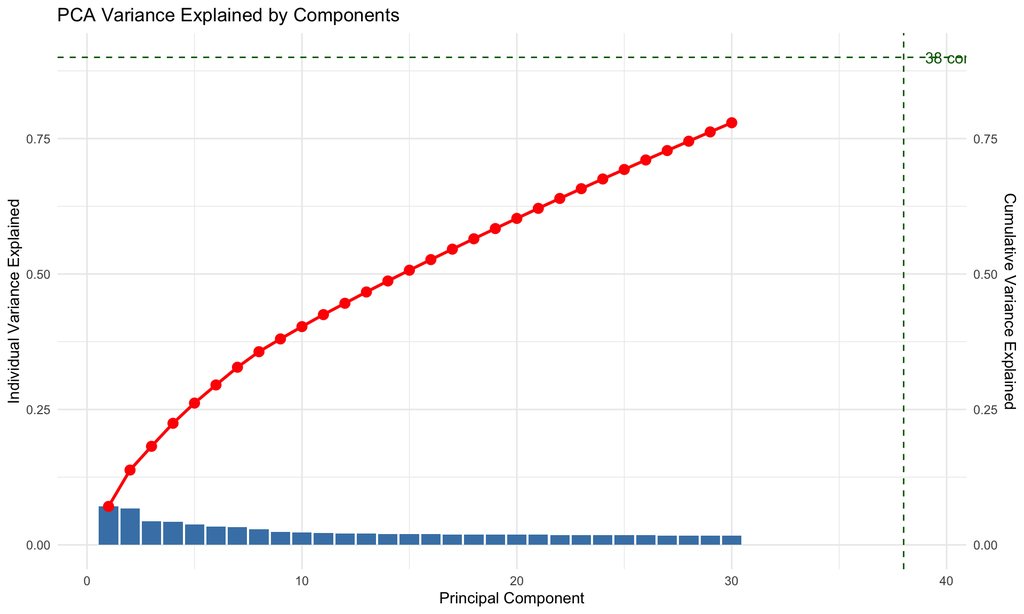

```r
# Plot variance explained
variance_df <- data.frame(
  Component = 1:length(variance_explained),
  Individual_Variance = variance_explained,
  Cumulative_Variance = cumulative_variance
)

ggplot(variance_df[1:min(30, nrow(variance_df)),], aes(x = Component)) +
  geom_bar(aes(y = Individual_Variance), stat = "identity", fill = "steelblue") +
  geom_line(aes(y = Cumulative_Variance, group = 1), color = "red", size = 1) +
  geom_point(aes(y = Cumulative_Variance), color = "red", size = 3) +
  geom_hline(yintercept = 0.9, linetype = "dashed", color = "darkgreen") +
  geom_vline(xintercept = n_components, linetype = "dashed", color = "darkgreen") +
  scale_y_continuous(sec.axis = sec_axis(~., name = "Cumulative Variance Explained")) +
  labs(title = "PCA Variance Explained by Components",
       x = "Principal Component",
       y = "Individual Variance Explained") +
  theme_minimal() +
  annotate("text", x = n_components + 1, y = 0.9,
           label = paste(n_components, "components for 90% variance"),
           color = "darkgreen", hjust = 0)
```

```r
# Create PCA-transformed datasets
train_pca <- predict(pca_model, train_normalized)[, 1:n_components]
valid_pca <- predict(pca_model, valid_normalized)[, 1:n_components]

# Add the target variable back
train_pca_df <- as.data.frame(train_pca)
train_pca_df$demand_proxy <- train_set$demand_proxy
valid_pca_df <- as.data.frame(valid_pca)
valid_pca_df$demand_proxy <- valid_set$demand_proxy
```

# Model Training with Cross-Validation

We’ll train multiple model types with cross-validation to find the one that performs best while avoiding overfitting.

```r
# Setup parallel processing for faster model training
num_cores <- detectCores() - 1
cl <- makeCluster(num_cores)
registerDoParallel(cl)

# Define cross-validation settings
cv_control <- trainControl(
  method = "cv",
  number = 5,
  verboseIter = TRUE,
  savePredictions = "final",
  allowParallel = TRUE
)
```

## Random Forest with Hyperparameter Tuning

```r
# Define hyperparameter grid for tuning Random Forest
rf_grid <- expand.grid(
  mtry = c(floor(sqrt(n_components)), floor(n_components/3), floor(n_components/2))
)

# Train Random Forest on PCA-transformed data with cross-validation
start_time_rf <- Sys.time()
rf_model_cv <- train(
  demand_proxy ~ .,
  data = train_pca_df,
  method = "rf",
  ntree = 500,
  importance = TRUE,
  trControl = cv_control,
  tuneGrid = rf_grid
)
end_time_rf <- Sys.time()
training_time_rf <- difftime(end_time_rf, start_time_rf, units = "mins")

# Show best parameters
cat("Best Random Forest parameters:", "\n")
print(rf_model_cv$bestTune)
cat(paste("Random Forest training time:", round(training_time_rf, 2), "minutes"))
```

[output not shown]

## Gradient Boosting Machine (GBM)

```r
# Define hyperparameter grid for GBM
gbm_grid <- expand.grid(
  n.trees = c(100, 500),
  interaction.depth = c(3, 5, 7),
  shrinkage = c(0.01, 0.1),
  n.minobsinnode = 10
)

# Train GBM with cross-validation
start_time_gbm <- Sys.time()
gbm_model_cv <- train(
  demand_proxy ~ .,
  data = train_pca_df,
  method = "gbm",
  trControl = cv_control,
  tuneGrid = gbm_grid,
  verbose = FALSE
)
end_time_gbm <- Sys.time()
training_time_gbm <- difftime(end_time_gbm, start_time_gbm, units = "mins")

# Show best parameters
cat("Best GBM parameters:", "\n")
print(gbm_model_cv$bestTune)
cat(paste("GBM training time:", round(training_time_gbm, 2), "minutes"))
```

[output not shown]

## Elastic Net Regression

```r
# Define hyperparameter grid for Elastic Net
glmnet_grid <- expand.grid(
  alpha = seq(0, 1, by = 0.2),  # 0 = ridge, 1 = lasso, in between = elastic net
  lambda = 10^seq(-4, -1, by = 0.5)
)

# Train Elastic Net with cross-validation
start_time_glmnet <- Sys.time()
glmnet_model_cv <- train(
  demand_proxy ~ .,
  data = train_pca_df,
  method = "glmnet",
  trControl = cv_control,
  tuneGrid = glmnet_grid
)
end_time_glmnet <- Sys.time()
training_time_glmnet <- difftime(end_time_glmnet, start_time_glmnet, units = "mins")

# Show best parameters
cat("Best Elastic Net parameters:", "\n")
print(glmnet_model_cv$bestTune)
cat(paste("Elastic Net training time:", round(training_time_glmnet, 2), "minutes"))

# Stop parallel processing
stopCluster(cl)
```

[output not shown]

# Model Evaluation and Comparison

Now we’ll compare all models to select the best one.

```r
# Create a function to calculate evaluation metrics
calculate_metrics <- function(actual, predicted, model_name) {
  rmse <- sqrt(mean((actual - predicted)^2, na.rm = TRUE))
  mae <- mean(abs(actual - predicted), na.rm = TRUE)
  r_squared <- 1 - sum((actual - predicted)^2, na.rm = TRUE) /
               sum((actual - mean(actual, na.rm = TRUE))^2, na.rm = TRUE)

  data.frame(
    model = model_name,
    rmse = rmse,
    mae = mae,
    r_squared = r_squared
  )
}

# Make predictions on validation set using each model
rf_predictions <- predict(rf_model_cv, valid_pca_df)
gbm_predictions <- predict(gbm_model_cv, valid_pca_df)
glmnet_predictions <- predict(glmnet_model_cv, valid_pca_df)

# Calculate metrics for each model
rf_metrics <- calculate_metrics(valid_pca_df$demand_proxy, rf_predictions, "Random Forest (PCA)")
gbm_metrics <- calculate_metrics(valid_pca_df$demand_proxy, gbm_predictions, "Gradient Boosting (PCA)")
glmnet_metrics <- calculate_metrics(valid_pca_df$demand_proxy, glmnet_predictions, "Elastic Net (PCA)")

# Combine metrics
all_metrics <- rbind(rf_metrics, gbm_metrics, glmnet_metrics)
all_metrics$training_time_mins <- c(
  as.numeric(training_time_rf),
  as.numeric(training_time_gbm),
  as.numeric(training_time_glmnet)
)
all_metrics$num_features_original <- length(features)
all_metrics$num_pca_components <- n_components

# Display evaluation metrics
kable(all_metrics,
     caption = "Model Performance Comparison",
     digits = 4)
```

Model Performance Comparison

| model | rmse | mae | r_squared | training_time_mins | num_features_original | num_pca_components |
| --- | --- | --- | --- | --- | --- | --- |
| Random Forest (PCA) | 0.0516 | 0.0359 | 0.9137 | 7.3428 | 30 | 38 |
| Gradient Boosting (PCA) | 0.0406 | 0.0302 | 0.9467 | 0.8890 | 30 | 38 |
| Elastic Net (PCA) | 0.0800 | 0.0650 | 0.7924 | 0.0147 | 30 | 38 |

```r
# Determine the best model based on RMSE
best_model_idx <- which.min(all_metrics$rmse)
best_model_name <- all_metrics$model[best_model_idx]
cat(paste("Best model based on RMSE:", best_model_name))
```

```
## Best model based on RMSE: Gradient Boosting (PCA)
```

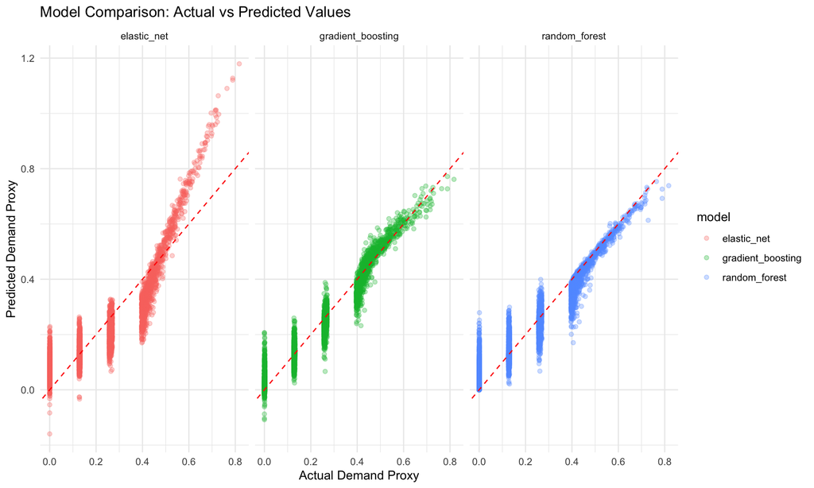

```r
# Create a data frame with actual and predicted values for all models
predictions_df <- data.frame(
  actual = valid_pca_df$demand_proxy,
  random_forest = rf_predictions,
  gradient_boosting = gbm_predictions,
  elastic_net = glmnet_predictions
)

# Create a long format data frame for plotting
predictions_long <- predictions_df %>%
  pivot_longer(cols = c(random_forest, gradient_boosting, elastic_net),
               names_to = "model", values_to = "predicted")

# Scatter plot of actual vs predicted values for all models
ggplot(predictions_long, aes(x = actual, y = predicted, color = model)) +
  geom_point(alpha = 0.3) +
  geom_abline(intercept = 0, slope = 1, color = "red", linetype = "dashed") +
  facet_wrap(~model) +
  labs(title = "Model Comparison: Actual vs Predicted Values",
       x = "Actual Demand Proxy",
       y = "Predicted Demand Proxy") +
  theme_minimal()
```

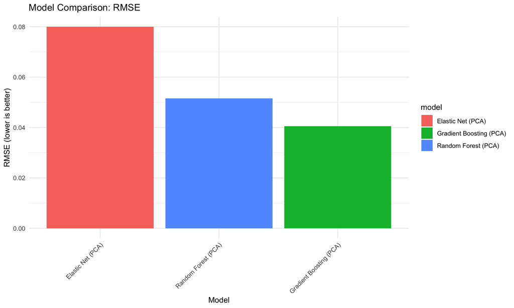

```r
# Bar plot comparing RMSE values
ggplot(all_metrics, aes(x = reorder(model, -rmse), y = rmse, fill = model)) +
  geom_bar(stat = "identity") +
  labs(title = "Model Comparison: RMSE",
       x = "Model",
       y = "RMSE (lower is better)") +
  theme_minimal() +
  theme(axis.text.x = element_text(angle = 45, hjust = 1))
```

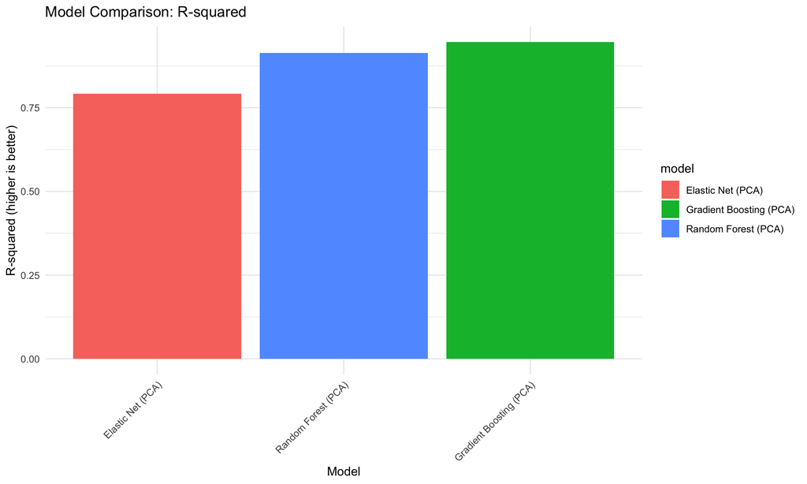

```r
# Bar plot comparing R-squared values
ggplot(all_metrics, aes(x = reorder(model, r_squared), y = r_squared, fill = model)) +
  geom_bar(stat = "identity") +
  labs(title = "Model Comparison: R-squared",
       x = "Model",
       y = "R-squared (higher is better)") +
  theme_minimal() +
  theme(axis.text.x = element_text(angle = 45, hjust = 1))
```

# Feature Importance

Let’s examine the feature importance based on the best model.

```
## caret's varImp failed: could not find function "relative.influence"
## Standard varImp failed for GBM, using permutation importance method...
## Testing importance of variable: PC1
## Testing importance of variable: PC2
## Testing importance of variable: PC3
## Testing importance of variable: PC4
## Testing importance of variable: PC5
## Testing importance of variable: PC6
## Testing importance of variable: PC7
## Testing importance of variable: PC8
## Testing importance of variable: PC9
## Testing importance of variable: PC10
## Permutation-based importance calculated for 10 variables
```

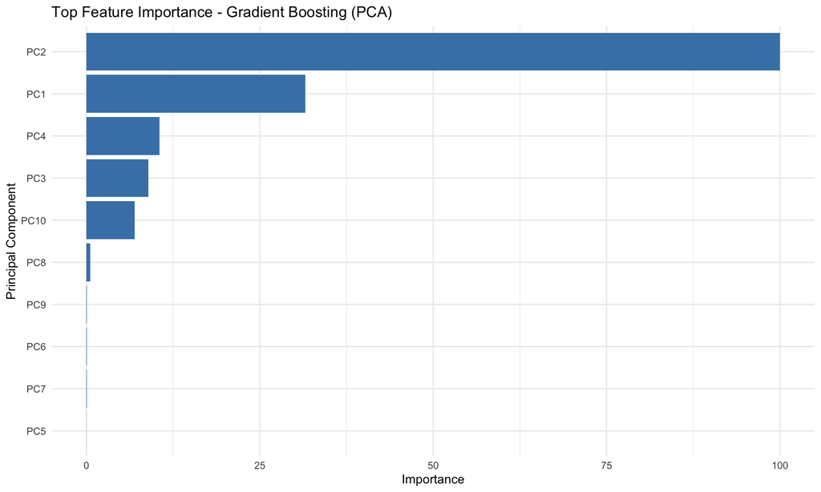

```r
# Extract feature importance based on the best model
if (best_model_name == "Random Forest (PCA)") {
  # Get variable importance from Random Forest
  rf_importance <- varImp(rf_model_cv)
  importance_df <- data.frame(
    feature = rownames(rf_importance$importance),
    importance = rf_importance$importance$Overall
  ) %>% arrange(desc(importance))

  # Plot feature importance
  ggplot(importance_df[1:min(20, nrow(importance_df)),],
       aes(x = reorder(feature, importance), y = importance)) +
    geom_bar(stat = "identity", fill = "steelblue") +
    coord_flip() +
    labs(title = paste("Top Feature Importance -", best_model_name),
         x = "Principal Component",
         y = "Importance") +
    theme_minimal()

  # Analyze PCA component loadings to interpret important components
  cat("Analyzing PCA component loadings for interpretation...\n")
  # Get top loadings for the most important components
  top_components <- importance_df$feature[1:5]  # Top 5 components

  # Extract the original feature loadings for these components
  loadings_df <- data.frame()

  for (comp in top_components) {
    comp_num <- as.numeric(gsub("PC", "", comp))

    # Get loadings for this component
    loadings <- pca_model$rotation[, comp_num]

    # Get top features with highest absolute loadings
    top_loadings <- sort(abs(loadings), decreasing = TRUE)[1:10]
    top_features <- names(top_loadings)

    # Create a data frame with the loadings
    comp_df <- data.frame(
      component = comp,
      feature = top_features,
      loading = loadings[top_features]
    )

    loadings_df <- rbind(loadings_df, comp_df)
  }

  # Display top loadings
  kable(loadings_df,
       caption = "Top Feature Loadings for Important PCA Components",
       digits = 3)

} else if (best_model_name == "Gradient Boosting (PCA)") {
  # Initialize importance_df to ensure it exists even if both methods fail
  importance_df <- data.frame(
    feature = colnames(valid_pca_df)[colnames(valid_pca_df) != "demand_proxy"],
    importance = 1  # Default equal importance if both methods fail
  )

  # Handle GBM importance differently to avoid the relative.influence issue
  success <- FALSE

  # First try the caret varImp method
  tryCatch({
    # Try using varImp if it works
    gbm_importance <- varImp(gbm_model_cv)
    if (!is.null(gbm_importance) && !is.null(gbm_importance$importance)) {
      importance_df <- data.frame(
        feature = rownames(gbm_importance$importance),
        importance = gbm_importance$importance$Overall
      ) %>% arrange(desc(importance))
      success <- TRUE
      cat("Using caret's varImp function for feature importance\n")
    }
  }, error = function(e) {
    cat("caret's varImp failed:", e$message, "\n")
  })

  # If the first method failed, try the permutation approach
  if (!success) {
    cat("Standard varImp failed for GBM, using permutation importance method...\n")

    # Use the variable importance based on the permutation approach (model agnostic)
    # Create an importance table based on which variables increased error when permuted
    set.seed(123)
    var_imp <- data.frame(feature = colnames(valid_pca_df)[colnames(valid_pca_df) != "demand_proxy"])
    var_imp$importance <- 0

    # Get baseline prediction error
    baseline_pred <- predict(gbm_model_cv, valid_pca_df)
    baseline_error <- mean((valid_pca_df$demand_proxy - baseline_pred)^2)

    # For each variable, permute it and see how much error increases
    # For speed, only test the first 10 variables
    for (i in 1:min(10, nrow(var_imp))) {
      curr_var <- var_imp$feature[i]
      cat("Testing importance of variable:", curr_var, "\n")

      temp_data <- valid_pca_df
      # Permute the variable
      temp_data[[curr_var]] <- sample(temp_data[[curr_var]])
      # Get predictions with permuted data
      perm_pred <- predict(gbm_model_cv, temp_data)
      # Calculate error
      perm_error <- mean((valid_pca_df$demand_proxy - perm_pred)^2)
      # Store importance as increase in error
      var_imp$importance[i] <- perm_error - baseline_error
    }

    # Ensure we have positive values (some might be negative due to randomness)
    var_imp$importance <- pmax(0, var_imp$importance)

    # If all importances are 0, set them all to 1 (equal importance)
    if (sum(var_imp$importance) == 0) {
      var_imp$importance <- 1
    }

    # Normalize importance values
    if (max(var_imp$importance) > 0) {
      var_imp$importance <- var_imp$importance / max(var_imp$importance) * 100
    }

    # Sort by importance
    importance_df <- var_imp %>% arrange(desc(importance))
    cat("Permutation-based importance calculated for", min(10, nrow(var_imp)), "variables\n")
  }

  # Plot feature importance
  ggplot(importance_df[1:min(10, nrow(importance_df)),],
       aes(x = reorder(feature, importance), y = importance)) +
    geom_bar(stat = "identity", fill = "steelblue") +
    coord_flip() +
    labs(title = paste("Top Feature Importance -", best_model_name),
         x = "Principal Component",
         y = "Importance") +
    theme_minimal()

} else {
  # For Elastic Net, get variable importance (coefficients)
  glmnet_importance <- varImp(glmnet_model_cv)
  importance_df <- data.frame(
    feature = rownames(glmnet_importance$importance),
    importance = glmnet_importance$importance$Overall
  ) %>% arrange(desc(importance))

  # Plot feature importance
  ggplot(importance_df[1:min(20, nrow(importance_df)),],
       aes(x = reorder(feature, importance), y = importance)) +
    geom_bar(stat = "identity", fill = "steelblue") +
    coord_flip() +
    labs(title = paste("Top Feature Importance -", best_model_name),
         x = "Principal Component",
         y = "Importance") +
    theme_minimal()
}
```

```r
# Display top important components
kable(head(importance_df, 10),
     caption = paste("Top 10 Most Important Components for", best_model_name),
     digits = 3)
```

Top 10 Most Important Components for Gradient Boosting (PCA)

| feature | importance |
| --- | --- |
| PC2 | 100.000 |
| PC1 | 31.544 |
| PC4 | 10.524 |
| PC3 | 8.951 |
| PC10 | 6.936 |
| PC8 | 0.550 |
| PC9 | 0.059 |
| PC6 | 0.058 |
| PC7 | 0.041 |
| PC5 | 0.013 |

# Model Saving

Finally, we save all the trained models and preprocessing steps for later use.

```r
# Save the models
saveRDS(rf_model_cv, paste0(models_path, "random_forest_pca_model.rds"))
saveRDS(gbm_model_cv, paste0(models_path, "gbm_pca_model.rds"))
saveRDS(glmnet_model_cv, paste0(models_path, "glmnet_pca_model.rds"))

# Also save the PCA model and preprocessing steps for later use in predictions
saveRDS(pca_model, paste0(models_path, "pca_model.rds"))
saveRDS(preproc, paste0(models_path, "preproc_model.rds"))
saveRDS(dummy_model, paste0(models_path, "dummy_model.rds"))

# Also save the original RandomForest model for backward compatibility
# This model will be used by the existing simulation script
if (best_model_name == "Random Forest (PCA)") {
  saveRDS(rf_model_cv$finalModel, paste0(models_path, "random_forest_model.rds"))
  cat("Saved RandomForest model for backward compatibility\n")
}

# Save model results for reporting
write.csv(all_metrics, paste0(results_path, "model_performance_metrics.csv"), row.names = FALSE)
write.csv(importance_df, paste0(results_path, "feature_importance.csv"), row.names = FALSE)

cat("Models saved to", models_path, "\n")
cat("Evaluation results saved to", results_path, "\n")
```

[output not shown]

# Conclusion

The best performing model was the **Gradient Boosting (PCA)** with: - **RMSE**: 0.0406 (Root Mean Squared Error) - **MAE**: 0.0302 (Mean Absolute Error) - **R-squared**: 0.9467 (Coefficient of Determination)

```r
# Display summary based on whether model was too good (suggesting overfitting)
if (all_metrics$r_squared[best_model_idx] > 0.95) {
  cat("⚠️ **Warning:** The R-squared value is suspiciously high, suggesting that the model might still be overfitting. Consider:")
  cat("\n- Further reducing model complexity")
  cat("\n- Collecting more training data")
  cat("\n- Using more aggressive regularization")
  cat("\n- Exploring simpler model architectures")
}
```

By using PCA to reduce dimensionality and cross-validation to tune hyperparameters, we’ve created a more robust model that should generalize better to new data compared to the previous approach.

In the next step, we’ll use this improved model for simulation to understand how changes in property characteristics might affect demand.